# Redes neuronales y deep learning

# Caso Práctico: análisis de un problema de regresión con Deep Learning

Daniel González  
Semana 3: Ajuste de modelos de Deep Learning  
IEBS

## Índice

- Caso práctico
  - Parte obligatoria
  - Parte opcional
  - Objetivos
  - Criterios de entrega
  - Temporalización
- California Housing Dataset
- Establecer una función de coste adecuada a nuestro problema
- Overfitting sobre un pequeño conjunto de datos
  - Ejercicio 1
  - Ejercicio 2
  - Ejercicio 3
  - Ejercicio 4
  - Ejercicio 5
- Elegimos un Optimizer
  - Ejercicio 6
  - Ejercicio 7
  - Ejercicio 8
- Probar diferentes configuraciones con un número pequeño de epochs
  - Ejercicio 9
  - Ejercicio 10
- Ajuste refinado de los parámetros con más epochs
  - Ejercicio 11
  - Ejercicio 12

```python
import tensorflow as tf
import numpy as np
import pandas as pd

# Para mostrar gráficas
import matplotlib.pyplot as plt
%matplotlib inline

# Anaconda fixing problem
import os
os.environ['KMP_DUPLICATE_LIB_OK']='True'
```

# Caso práctico

El objetivo de este caso práctico es simular como se haría un análisis completo de un problema para resolverlo con Deep Learning. Nos pondremos en la piel de un *data scientist* dedicado a analizar y crear modelos de Deep Learning para pasarlos a producción y ser desplegados en una aplicación.

**Destacar que este caso práctico es la continuación de la última actividad realizada en la semana anterior. En la actividad de la semana anterior encontramos la mejor arquitectura para los datos que tenemos y ahora vmoas a realizar más experimentos jugando con los optimizers y el valor del learning rate.**

Imaginemos que tenemos un dataset completo que queremos explotar, nuestra labor será coger este dataset (California Housing Dataset) y desde 0 intentar llegar conseguir un modelo que tenga un buen rendimiento ajustándolo poco a poco como hemos visto en clase. Por lo que tendrmeos que entrerar distintas redes y comparar los resultados que obtengamos en cada experimento para ver cual es mejor.

Cada experimento que tendremos que realizar estará bien definido, la red que deberéis crear y entrenar será proporcinada por lo que solamente tendréis que crear la red que se nos indica con TensorFlow y realizar el entrenamiento de la misma.

## Parte obligatoria

Será obligatorio realizar cada uno de los ejercicios que están definidos. En cada ejercicio está definida la red que se tiene que crear y la configuración con la que se tiene que entrenar, por lo que solamente tendréis que pasar esa definición a código con TensorFlow.

Para tener una buena práctica en la realización de este caso práctico se ofrecen esta recomendaciones:

- Utiliza correctamente el sistema de celdas de jupyter. La libreta está realizada de tal forma que solo tendréis que completar las celdas que se indican, ya sea con código o con texto en markdown. Se recomienda rellenar solamente las celdas indicadas para que quede un informe limpio y fácil de seguir. Si fuera necesario incluir más celdas por cualquier motivo se puede hacer pero realizarlo con cuidado para no ensuciar demasiado la libreta.
- Las redes que tendréis que crear en cada experimento son las vistas en clase, por lo que os podéis inspirar en los ejemplos vistos en los tutoriales. Os recomiendo que no copiéis y peguéis código tal cual, sino que lo escribáis por vuestra cuenta y entendáis lo que estáis haciendo en cada momento. Tomaros el tiempo que haga falta para entender cada paso.
- Comprueba que todo se ejecuta correctamente antes de enviar tu trabajo. La mejor forma de enviarlo es exportando la libreta a pdf o html para enviarla en un formato más profesional.

## Parte opcional

La parte opcional son los últimos ejercicios donde tendréis que sacar una conclusión de si la red que habéis llegado a conseguir tiene un buen rendimiento.

## Objetivos

- Cargar y entender los datos del dataset California Housing con los que se trabajarán.
- Crear cada una de las redes indicadas en los experimentos.
- Entrenar cada una de las redes creadas en los experimentos.
- Entender los resultados obtenidos en cada entrenamiento.

## Criterios de entrega

Se deberá entregar una libreta de jupyter, aunque se agradecerá que el formato entregado se html o pdf, el trabajo debe estar autocontenido, incluyendo código y texto explicativo para cada sección.

# California Housing Dataset

En este notebook vamos a usar un dataset nuevo, el dataset es muy parecido al dataset del precio de las casas de boston. Esta vez vamos a utilizar un conjunto de datos que contienen información sobre el precio de las casas encontradas en un distrito de California. Las columnas son las siguientes:

- *longitude*: cuanto de al oeste está una casa; un valor más alto está más al oeste.
- *latitude*: cuanto de al norte está una casa; un valor más alto está más al norte.
- _housing_median*age*: edad media de una casa; un valor bajo es una casa más nueva.
- _total*rooms*: número total de habitaciones.
- _total*bedrooms*: número total de dormitorios.
- *population*: número total de personas que residen.
- *households*: número total de hogares, un grupo de personas que residen dentro de una unidad de vivienda.
- _median*income*: ingreso medio de los hogares dentro de un bloque de casas (medido en decenas de miles de dólares).
- _ocean*proximity*: ubicación de la casa cerca del océano o mar.
- _median_house*value (**variables a predecir**)*: valor medio de la vivienda (medido en dólares).

Vamos a cargar los datos desde el fichero `housing.csv`:

```python
df = pd.read_csv('housing.csv')
```

```python
df.head()
```

|  | longitude | latitude | housing_median_age | total_rooms | total_bedrooms | population | households | median_income | ocean_proximity | median_house_value |
| --- | --- | --- | --- | --- | --- | --- | --- | --- | --- | --- |
| 0 | -122.23 | 37.88 | 41.0 | 880.0 | 129.0 | 322.0 | 126.0 | 8.3252 | 3 | 452600.0 |
| 1 | -122.22 | 37.86 | 21.0 | 7099.0 | 1106.0 | 2401.0 | 1138.0 | 8.3014 | 3 | 358500.0 |
| 2 | -122.24 | 37.85 | 52.0 | 1467.0 | 190.0 | 496.0 | 177.0 | 7.2574 | 3 | 352100.0 |
| 3 | -122.25 | 37.85 | 52.0 | 1274.0 | 235.0 | 558.0 | 219.0 | 5.6431 | 3 | 341300.0 |
| 4 | -122.25 | 37.85 | 52.0 | 1627.0 | 280.0 | 565.0 | 259.0 | 3.8462 | 3 | 342200.0 |

```python
df.shape
```

```
(20433, 10)
```

Vamos a separar la variable objetivo del resto de variables (accedemos al campo value para que los datos sean de tipo *numpy array* y se puedan usar como variable de entrada de nuestra red):

```python
df.columns
```

```
Index(['longitude', 'latitude', 'housing_median_age', 'total_rooms',
       'total_bedrooms', 'population', 'households', 'median_income',
       'ocean_proximity', 'median_house_value'],
      dtype='object')
```

```python
x = df[['longitude', 'latitude', 'housing_median_age', 'total_rooms',
       'total_bedrooms', 'population', 'households', 'median_income',
       'ocean_proximity']].values
y = df[['median_house_value']].values
```

## 1. Establecer una función de coste adecuada a nuestro problema.

```python
actual_loss = 'mean_absolute_percentage_error'
```

## 2. Overfitting sobre un pequeño conjunto de datos.

Ahora, como ya hemos visto en clase vamos a encontrar una estructura de red que encaje con los datos que vamos a utilizar. Vamos a crear varias redes a ver que talfuncionan.

Para hacer entrenamientos rápidos y ver si la red se adapta a los datos vamos a usar solo un subconjunto de los datos, es decir usaremos 1000 datos y no usaremos conjunto de validación.

### Ejercicio 1

Crear una red con la siguiente configuración y entrénala:

- **Configuración de la red**:
  - Arquitectura de la red:
    - *1º Capa*: capa de entrada donde indiques la dimensión de los datos.
    - *2º Capa*: capa densa con 8 neuronas y función de activación *relu*.
    - *3º Capa*: capa densa con 8 neuronas y función de activación *relu*.
    - *4º Capa*: capa de salida con una neurona sin función de activación.
  - Tipo de entrenamiento:
    - *Epochs*: 30
    - *Optimizador*: *adam*
    - *Learning Rate*: 0.001

*En los datos de entrada ponemos 9, porque con df.shape hemos visto que tenemos 10 columnas, pero como luego dividimos los datos en Y pusimos la variable independiente, nos quedan 9 datos de entrada que los hemos asignado en X.*

```python
# Configuramos la red
model1 = tf.keras.models.Sequential([
    tf.keras.layers.Input(shape=9),
    tf.keras.layers.Dense(8, activation = 'relu'),
    tf.keras.layers.Dense(8, activation = 'relu'),
    tf.keras.layers.Dense(1)
])

# Especificamos el Optimizador
opt1 = tf.keras.optimizers.Adam(
    learning_rate = 0.001
)

# Compilamos el modelo
model1.compile(
    optimizer= opt1,
    loss = actual_loss,
    metrics = actual_loss
)

# Entrenamos el modelo
hist1 = model1.fit(x[0:1000], y[0:1000], epochs=30)
```

*El error empieza de 99 y baja hasta casi 44.*

### Ejercicio 2

Vamos a complicar un poco más la arquitectura de la red:

- **Configuración de la red**:
  - Arquitectura de la red:
    - *1º Capa*: capa de entrada donde indiques la dimensión de los datos.
    - *2º Capa*: capa densa con 64 neuronas y función de activación *relu*.
    - *3º Capa*: capa densa con 32 neuronas y función de activación *relu*.
    - *4º Capa*: capa densa con 32 neuronas y función de activación *relu*.
    - *5º Capa*: capa de salida con una neurona sin función de activación.
  - Tipo de entrenamiento:
    - *Epochs*: 30
    - *Optimizador*: *adam*
    - *Learning Rate*: 0.001

```python
# Configuramos la red
model2 = tf.keras.models.Sequential([
    tf.keras.layers.Input(shape=9),
    tf.keras.layers.Dense(64, activation = 'relu'),
    tf.keras.layers.Dense(32, activation = 'relu'),
    tf.keras.layers.Dense(32, activation = 'relu'),
    tf.keras.layers.Dense(1)
])

# Especificamos el Optimizador
opt2 = tf.keras.optimizers.Adam(
    learning_rate = 0.001
)

# Compilamos el modelo
model2.compile(
    optimizer= opt2,
    loss = actual_loss,
    metrics = actual_loss
)

# Entrenamos el modelo
hist2 = model2.fit(x[0:1000], y[0:1000], epochs=30)
```

*Poniendo mas capas densas el error empieza de 99.000 y baja hasta 29.000 casi.*

### Ejercicio 3

Vamos a complicar aun más la arquitectura de la red:

- **Configuración de la red**:
  - Arquitectura de la red:
    - *1º Capa*: capa de entrada donde indiques la dimensión de los datos.
    - *2º Capa*: capa densa con 128 neuronas y función de activación *relu*.
    - *3º Capa*: capa densa con 64 neuronas y función de activación *relu*.
    - *4º Capa*: capa densa con 32 neuronas y función de activación *relu*.
    - *5º Capa*: capa densa con 16 neuronas y función de activación *relu*.
    - *6º Capa*: capa de salida con una neurona sin función de activación.
  - Tipo de entrenamiento:
    - *Epochs*: 30
    - *Optimizador*: *adam*
    - *Learning Rate*: 0.001

```python
# Configuramos la red
model3 = tf.keras.models.Sequential([
    tf.keras.layers.Input(shape=9),
    tf.keras.layers.Dense(128, activation = 'relu'),
    tf.keras.layers.Dense(64, activation = 'relu'),
    tf.keras.layers.Dense(32, activation = 'relu'),
    tf.keras.layers.Dense(16, activation = 'relu'),
    tf.keras.layers.Dense(1)
])

# Especificamos el Optimizador
opt3 = tf.keras.optimizers.Adam(
    learning_rate = 0.001
)

# Compilamos el modelo
model3.compile(
    optimizer= opt3,
    loss = actual_loss,
    metrics = actual_loss
)

# Entrenamos el modelo
hist3 = model3.fit(x[0:1000], y[0:1000], epochs=30)
```

*Nos da más o menos los mismos resultados que el anterior. El error empieza de 99.000 y llega al 26.000.*

### Ejercicio 4

Vamos a hacer una última red con más capas y neuronas:

- **Configuración de la red**:
  - Arquitectura de la red:
    - *1º Capa*: capa de entrada donde indiques la dimensión de los datos.
    - *2º Capa*: capa densa con 1024 neuronas y función de activación *relu*.
    - *3º Capa*: capa densa con 512 neuronas y función de activación *relu*.
    - *4º Capa*: capa densa con 256 neuronas y función de activación *relu*.
    - *5º Capa*: capa densa con 128 neuronas y función de activación *relu*.
    - *6º Capa*: capa densa con 64 neuronas y función de activación *relu*.
    - *7º Capa*: capa densa con 32 neuronas y función de activación *relu*.
    - *8º Capa*: capa densa con 16 neuronas y función de activación *relu*.
    - *9º Capa*: capa de salida con una neurona sin función de activación.
  - Tipo de entrenamiento:
    - *Epochs*: 30
    - *Optimizador*: *adam*
    - *Learning Rate*: 0.001

```python
# Configuramos la red
model4 = tf.keras.models.Sequential([
    tf.keras.layers.Input(shape=9),
    tf.keras.layers.Dense(1024, activation = 'relu'),
    tf.keras.layers.Dense(512, activation = 'relu'),
    tf.keras.layers.Dense(256, activation = 'relu'),
    tf.keras.layers.Dense(128, activation = 'relu'),
    tf.keras.layers.Dense(64, activation = 'relu'),
    tf.keras.layers.Dense(32, activation = 'relu'),
    tf.keras.layers.Dense(16, activation = 'relu'),
    tf.keras.layers.Dense(1)
])

# Especificamos el Optimizador
opt4 = tf.keras.optimizers.Adam(
    learning_rate = 0.001
)

# Compilamos el modelo
model4.compile(
    optimizer= opt4,
    loss = actual_loss,
    metrics = actual_loss
)

# Entrenamos el modelo
hist4 = model4.fit(x[0:1000], y[0:1000], epochs=30)
```

*Parece que este modelo nos da mejores resultados. Baja el error de 79 a 19.*

### Ejercicio 5

Compara los resultados obtenidos en cada una de las arquitecturas definidas y quédate con la mejor. **¿En qué experimento se obtiene los mejores resultados?**

La arquitectura elegida la usaremos en el caso práctico para seguir ajustando nuestro modelo y alcanzar un buen rendimiento.

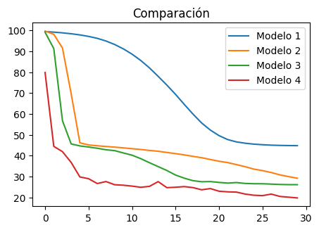

```python
# Comparampos los modelos

fig=plt.figure(figsize=(60, 40))

fig.add_subplot(10, 10, 1)
plt.title('Comparación')
plt.plot(hist1.history['loss'], label='Modelo 1')
plt.plot(hist2.history['loss'], label='Modelo 2')
plt.plot(hist3.history['loss'], label='Modelo 3')
plt.plot(hist4.history['loss'], label='Modelo 4')
plt.legend()
```

*Evidentemente el mejor modelo nos lo da el experimento 4 para la prueba con 1000 datos. El primer modelo empieza estancado luego baja el error. El segundo en cuando llega a 45% se estanca. El tercero casi igual que el segundo. El 4 tampoco esta perfecto, pero de los cuatro, el 4º es el que mejor aprende.*

*Nos quedamos con el 4º modelo.*

## 3. Elegimos un Optimizer.

Hemos establecido Adam en los entrenamientos anteriores. Vamos a comprobarlo para el conjunto de validación como funciona y después probaremos a usar un optimizador SGD.

### Ejercicio 6

Usa la mejor arquitectura y configuración de entrenamiento de los ejercicios anteriores y entrena con la siguiente configuración:

- Usa un `validation_split` de 0.2
- Utiliza todos los datos y no solo 1000.
- Usa 5 epochs en total.

```python
# Configuramos la red
model5 = tf.keras.models.Sequential([
    tf.keras.layers.Input(shape=9),
    tf.keras.layers.Dense(1024, activation = 'relu'),
    tf.keras.layers.Dense(512, activation = 'relu'),
    tf.keras.layers.Dense(256, activation = 'relu'),
    tf.keras.layers.Dense(128, activation = 'relu'),
    tf.keras.layers.Dense(64, activation = 'relu'),
    tf.keras.layers.Dense(32, activation = 'relu'),
    tf.keras.layers.Dense(16, activation = 'relu'),
    tf.keras.layers.Dense(1)
])

# Especificamos el Optimizador
opt5 = tf.keras.optimizers.Adam(
    learning_rate = 0.001
)

# Compilamos el modelo
model5.compile(
    optimizer= opt5,
    loss = actual_loss,
    metrics = actual_loss
)

# Entrenamos el modelo con 20% de los datos para el Test y para el Train todos los datos
hist5 = model5.fit(x, y, validation_split=0.2, epochs=5)
```

*Con todos los datos el error de Train empieza de 48 y baja hasta 33, el de Test de 50 a 35.*

### Ejercicio 7

Realiza el mismo entrenamiento que el ejercicio anterior pero usa un optimizador **SGD** en lugar de un Adam.

```python
# Configuramos la red
model6 = tf.keras.models.Sequential([
    tf.keras.layers.Input(shape=9),
    tf.keras.layers.Dense(1024, activation = 'relu'),
    tf.keras.layers.Dense(512, activation = 'relu'),
    tf.keras.layers.Dense(256, activation = 'relu'),
    tf.keras.layers.Dense(128, activation = 'relu'),
    tf.keras.layers.Dense(64, activation = 'relu'),
    tf.keras.layers.Dense(32, activation = 'relu'),
    tf.keras.layers.Dense(16, activation = 'relu'),
    tf.keras.layers.Dense(1)
])

# Especificamos el Optimizador
opt6 = tf.keras.optimizers.SGD(
    learning_rate = 0.001
)

# Compilamos el modelo
model6.compile(
    optimizer= opt6,
    loss = actual_loss,
    metrics = actual_loss
)

# Entrenamos el modelo
hist6 = model6.fit(x, y, validation_split=0.2, epochs=5)
```

*Con el Optimizador SGD el error empieza de 91 y baja hasta 50.*

### Ejercicio 8

**¿Qué optimizador ha funcionado mejor?**

El optimizador que eligas tendrás que usarlo en los siguientes ejercicios.

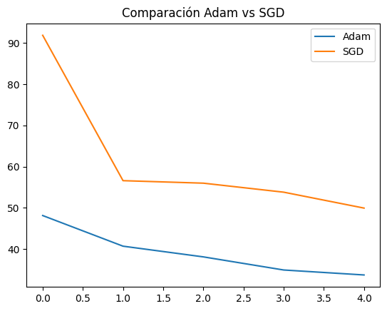

```python
fig.add_subplot(10, 10, 1)
plt.title('Comparación Adam vs SGD')
plt.plot(hist5.history['loss'], label='Adam')
plt.plot(hist6.history['loss'], label='SGD')
plt.legend()
```

*Pues NO. Mejor nos ha salido con el Optimizador Adam, porque con el SGD deja de aprender en cuando llegua a 55 y es un error muy alto. Adam aunque empieza de 47, nos da un error de 35 que es más aceptable que 55.*

## 4. Probar diferentes configuraciones con un número pequeño de epochs.

Vamos a realizar diferentes experimentos cambiando el learning rate de nuestro optimizador.

### Ejercicio 9

Realiza un entrenamiento con la arquitectura y el optimizador que mejor te ha funcionado y utilizar un **learning rate de 0.1**.

*Nos ha funcionado mejor la arquitectura de 1024, 512, 256, 128, 64, 32 y 16 neuronas con el Optimizador Adam.*

```python
# Configuramos la red
model7 = tf.keras.models.Sequential([
    tf.keras.layers.Input(shape=9),
    tf.keras.layers.Dense(1024, activation = 'relu'),
    tf.keras.layers.Dense(512, activation = 'relu'),
    tf.keras.layers.Dense(256, activation = 'relu'),
    tf.keras.layers.Dense(128, activation = 'relu'),
    tf.keras.layers.Dense(64, activation = 'relu'),
    tf.keras.layers.Dense(32, activation = 'relu'),
    tf.keras.layers.Dense(16, activation = 'relu'),
    tf.keras.layers.Dense(1)
])

# Especificamos el Optimizador
opt7 = tf.keras.optimizers.Adam(
    learning_rate = 0.1
)

# Compilamos el modelo
model7.compile(
    optimizer= opt7,
    loss = actual_loss,
    metrics = actual_loss
)

# Entrenamos el modelo
hist7 = model7.fit(x, y, validation_split=0.2, epochs=5)
```

### Ejercicio 10

Realiza el mismo entrenamiento que el ejercicio anterior pero esta vez usa un **learning rate de 0.0001**.

```python
# Configuramos la red
model8 = tf.keras.models.Sequential([
    tf.keras.layers.Input(shape=9),
    tf.keras.layers.Dense(1024, activation = 'relu'),
    tf.keras.layers.Dense(512, activation = 'relu'),
    tf.keras.layers.Dense(256, activation = 'relu'),
    tf.keras.layers.Dense(128, activation = 'relu'),
    tf.keras.layers.Dense(64, activation = 'relu'),
    tf.keras.layers.Dense(32, activation = 'relu'),
    tf.keras.layers.Dense(16, activation = 'relu'),
    tf.keras.layers.Dense(1)
])

# Especificamos el Optimizador
opt8 = tf.keras.optimizers.Adam(
    learning_rate = 0.0001
)

# Compilamos el modelo
model8.compile(
    optimizer= opt8,
    loss = actual_loss,
    metrics = actual_loss
)

# Entrenamos el modelo
hist8 = model8.fit(x, y, validation_split=0.2, epochs=5)
```

*Con el learning_rate = 0.0001 el error de Train baja a 41, pero el de Test a 46, lo que nos hace pensar que tenemos sobreajuste..*

## 5. Ajuste refinado de los parámetros con más epochs. [Opcional]

Por último vamos a realizar un entrenamiento más largo para ver hasta donde llega el rendimiento de nuestro modelo.

### Ejercicio 11 [Opcional]

**¿Entre los entrenamientos usando learning rates igual a 0.001, 0.1 y 0.0001 cual ha funcionado mejor?**

Con el experimento que mejor haya funcionado haz un entrenamiento usando 30 epochs y ver que tal funciona el entrenamiento con más epochs.

*Nos ha funcionado mejor el modelo con learning_rate = 0.001.*

```python
# Configuramos la red
model9 = tf.keras.models.Sequential([
    tf.keras.layers.Input(shape=9),
    tf.keras.layers.Dense(1024, activation = 'relu'),
    tf.keras.layers.Dense(512, activation = 'relu'),
    tf.keras.layers.Dense(256, activation = 'relu'),
    tf.keras.layers.Dense(128, activation = 'relu'),
    tf.keras.layers.Dense(64, activation = 'relu'),
    tf.keras.layers.Dense(32, activation = 'relu'),
    tf.keras.layers.Dense(16, activation = 'relu'),
    tf.keras.layers.Dense(1)
])

# Especificamos el Optimizador
opt9 = tf.keras.optimizers.Adam(
    learning_rate = 0.001
)

# Compilamos el modelo
model9.compile(
    optimizer= opt9,
    loss = actual_loss,
    metrics = actual_loss
)

# Entrenamos el modelo
hist9 = model9.fit(x, y, validation_split=0.2, epochs=30)
```

### Ejercicio 12 [Opcional]

Muestra en una gráfica como ha evolucionado el entrenamiento.

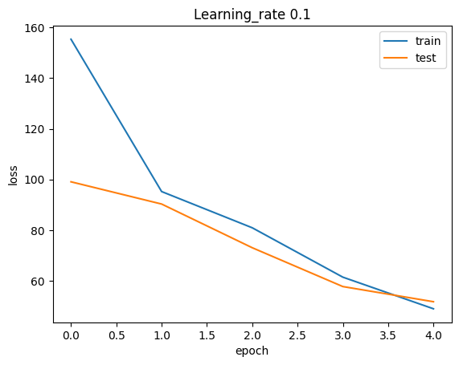

```python
#Vamos a ver en grafico los entrenamientos con los diferentes learning rates
plt.plot(hist7.history['loss'], label="train")
plt.plot(hist7.history['val_loss'], label="test")
plt.title('Learning_rate 0.1')
plt.ylabel('loss')
plt.xlabel('epoch')
plt.legend()
```

*Con el learning_rate 0.1 vemos que las predicciones son malas. El error demasiado alto.*

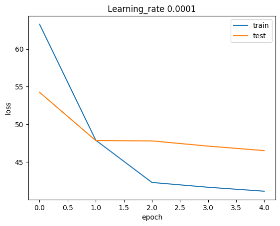

```python
# Learning_rate 0.0001
plt.plot(hist8.history['loss'], label="train")
plt.plot(hist8.history['val_loss'], label="test")
plt.title('Learning_rate 0.0001')
plt.ylabel('loss')
plt.xlabel('epoch')
plt.legend()
```

*Con este learning_rate tenemos demasiado sobreajuste y error del test muy alto también (47).*

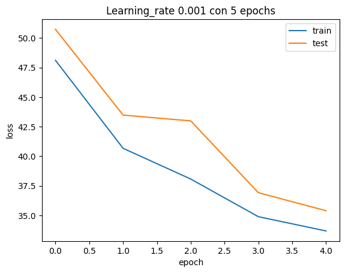

```python
# Learning_rate 0.001
plt.plot(hist5.history['loss'], label="train")
plt.plot(hist5.history['val_loss'], label="test")
plt.title('Learning_rate 0.001 con 5 epochs')
plt.ylabel('loss')
plt.xlabel('epoch')
plt.legend()
```

*Aquí vemos que las dos líneas se mueven más o menos igual, aunque también hay un pequeño sobreajuste.*

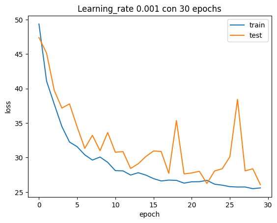

```python
#Vamos a verlo en grafico para el modelo de learning_rate = 0.001 y epochs 30
plt.plot(hist9.history['loss'], label="train")
plt.plot(hist9.history['val_loss'], label="test")
plt.title('Learning_rate 0.001 con 30 epochs')
plt.ylabel('loss')
plt.xlabel('epoch')
plt.legend()
```

*Con el learning_rate = 0.0001 y 0.1 nos ha ido mal.*

*Con el 0.001 es cuando mejor nos ha ido, el entrenamiento ha ido muy bien pero el test tiene muchos saltos.*

*No es el rendimiento que nos gustaría tener.*

*Vamos a intentar aplanar los saltos añadiendo alguna capa dropout.*

```python
# Configuramos la red
model10 = tf.keras.models.Sequential([
    tf.keras.layers.Input(shape=9),
    tf.keras.layers.Dense(1024, activation = 'relu'),
    tf.keras.layers.Dropout(0.25),
    tf.keras.layers.Dense(512, activation = 'relu'),
    tf.keras.layers.Dense(256, activation = 'relu'),
    tf.keras.layers.Dense(128, activation = 'relu'),
    tf.keras.layers.Dense(64, activation = 'relu'),
    tf.keras.layers.Dense(32, activation = 'relu'),
    tf.keras.layers.Dense(16, activation = 'relu'),
    tf.keras.layers.Dense(1)
])

# Especificamos el Optimizador
opt10 = tf.keras.optimizers.Adam(
    learning_rate = 0.001
)

# Compilamos el modelo
model10.compile(
    optimizer= opt10,
    loss = actual_loss,
    metrics = actual_loss
)

# Entrenamos el modelo
hist10 = model10.fit(x, y, validation_split=0.2, epochs=30)
```

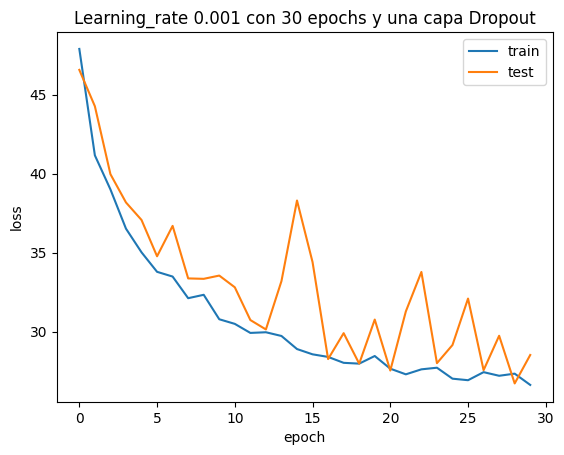

```python
# Grafico para el modelo de learning_rate = 0.001 y epochs 30 y una capa Dropout
plt.plot(hist10.history['loss'], label="train")
plt.plot(hist10.history['val_loss'], label="test")
plt.title('Learning_rate 0.001 con 30 epochs y una capa Dropout')
plt.ylabel('loss')
plt.xlabel('epoch')
plt.legend()
```

*Probamos una red eliminando la capa de 1024 neuronas y la capa Dropout.*

```python
# Configuramos la red
model11 = tf.keras.models.Sequential([
    tf.keras.layers.Input(shape=9),
    tf.keras.layers.Dense(512, activation = 'relu'),
    tf.keras.layers.Dense(256, activation = 'relu'),
    tf.keras.layers.Dense(128, activation = 'relu'),
    tf.keras.layers.Dense(64, activation = 'relu'),
    tf.keras.layers.Dense(32, activation = 'relu'),
    tf.keras.layers.Dense(16, activation = 'relu'),
    tf.keras.layers.Dense(1)
])

# Especificamos el Optimizador
opt11 = tf.keras.optimizers.Adam(
    learning_rate = 0.001
)

# Compilamos el modelo
model11.compile(
    optimizer= opt11,
    loss = actual_loss,
    metrics = actual_loss
)

# Entrenamos el modelo
hist11 = model11.fit(x, y, validation_split=0.2, epochs=30)
```

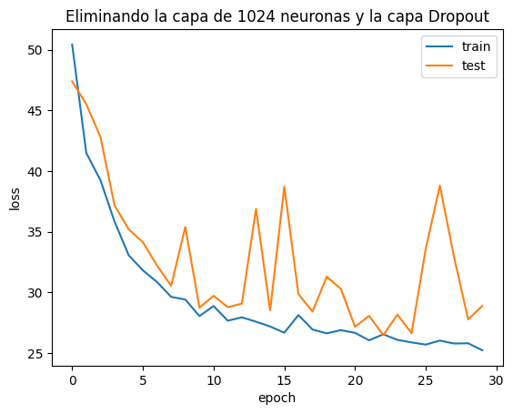

```python
# Grafico para el modelo de learning_rate = 0.001 y epochs 30 eliminando la capa de 1024 neuronas y la capa Dropout
plt.plot(hist11.history['loss'], label="train")
plt.plot(hist11.history['val_loss'], label="test")
plt.title('Eliminando la capa de 1024 neuronas y la capa Dropout')
plt.ylabel('loss')
plt.xlabel('epoch')
plt.legend()
```

*Tampoco nos gusta por los saltos.*

*Vamos a probar quedandonos con esta arquitectura pero añadiendo una capa dropout después de las 512 neuronas.*

```python
# Configuramos la red
model12 = tf.keras.models.Sequential([
    tf.keras.layers.Input(shape=9),
    tf.keras.layers.Dense(512, activation = 'relu'),
    tf.keras.layers.Dropout(0.25),
    tf.keras.layers.Dense(256, activation = 'relu'),
    tf.keras.layers.Dense(128, activation = 'relu'),
    tf.keras.layers.Dense(64, activation = 'relu'),
    tf.keras.layers.Dense(32, activation = 'relu'),
    tf.keras.layers.Dense(16, activation = 'relu'),
    tf.keras.layers.Dense(1)
])

# Especificamos el Optimizador
opt12 = tf.keras.optimizers.Adam(
    learning_rate = 0.001
)

# Compilamos el modelo
model12.compile(
    optimizer= opt12,
    loss = actual_loss,
    metrics = actual_loss
)

# Entrenamos el modelo
hist12 = model12.fit(x, y, validation_split=0.2, epochs=30)
```

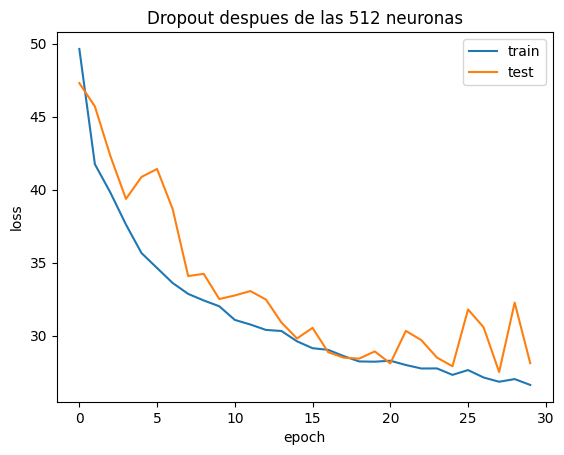

```python
# Grafico para el modelo de learning_rate = 0.001 y epochs 30 eliminando la capa de 1024 neuronas y añadiendo una capa Dropout después de las 512 neuronas
plt.plot(hist12.history['loss'], label="train")
plt.plot(hist12.history['val_loss'], label="test")
plt.title('Dropout despues de las 512 neuronas')
plt.ylabel('loss')
plt.xlabel('epoch')
plt.legend()
```

*Ha ido algo mejor. No son tan altos los saltos.*

*Vamos a añadir otra capa Dropout despues de las 256 neuronas.*

```python
# Configuramos la red
model13 = tf.keras.models.Sequential([
    tf.keras.layers.Input(shape=9),
    tf.keras.layers.Dense(512, activation = 'relu'),
    tf.keras.layers.Dropout(0.25),
    tf.keras.layers.Dense(256, activation = 'relu'),
     tf.keras.layers.Dropout(0.25),
    tf.keras.layers.Dense(128, activation = 'relu'),
    tf.keras.layers.Dense(64, activation = 'relu'),
    tf.keras.layers.Dense(32, activation = 'relu'),
    tf.keras.layers.Dense(16, activation = 'relu'),
    tf.keras.layers.Dense(1)
])

# Especificamos el Optimizador
opt13 = tf.keras.optimizers.Adam(
    learning_rate = 0.001
)

# Compilamos el modelo
model13.compile(
    optimizer= opt13,
    loss = actual_loss,
    metrics = actual_loss
)

# Entrenamos el modelo
hist13 = model13.fit(x, y, validation_split=0.2, epochs=30)
```

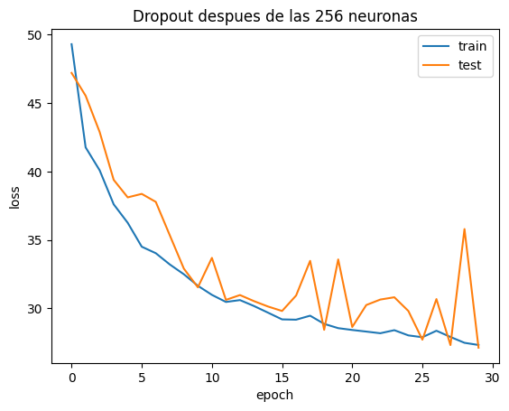

```python
# Añadiendo otra capa Dropout despues de las 256 neuronas
plt.plot(hist13.history['loss'], label="train")
plt.plot(hist13.history['val_loss'], label="test")
plt.title('Dropout despues de las 256 neuronas')
plt.ylabel('loss')
plt.xlabel('epoch')
plt.legend()
```

*Sin la segunda capa de Dropout los resultados son mejores. Los saltos por lo menos no superan el error de 35.*

*Vamos a poner el valor de la capa Dropout despues de las 512 neuronas a 40 y eliminar la segunda a ver que resultados nos da.*

```python
# Configuramos la red
model14 = tf.keras.models.Sequential([
    tf.keras.layers.Input(shape=9),
    tf.keras.layers.Dense(512, activation = 'relu'),
    tf.keras.layers.Dropout(0.40),
    tf.keras.layers.Dense(256, activation = 'relu'),
    tf.keras.layers.Dense(128, activation = 'relu'),
    tf.keras.layers.Dense(64, activation = 'relu'),
    tf.keras.layers.Dense(32, activation = 'relu'),
    tf.keras.layers.Dense(16, activation = 'relu'),
    tf.keras.layers.Dense(1)
])

# Especificamos el Optimizador
opt14 = tf.keras.optimizers.Adam(
    learning_rate = 0.001
)

# Compilamos el modelo
model14.compile(
    optimizer= opt14,
    loss = actual_loss,
    metrics = actual_loss
)

# Entrenamos el modelo
hist14 = model14.fit(x, y, validation_split=0.2, epochs=30)
```

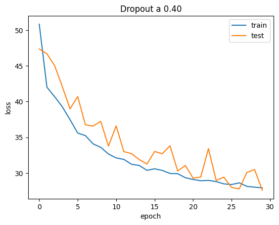

```python
# Modificando el valor de la capa Dropout a 0.4
plt.plot(hist14.history['loss'], label="train")
plt.plot(hist14.history['val_loss'], label="test")
plt.title('Dropout a 0.40')
plt.ylabel('loss')
plt.xlabel('epoch')
plt.legend()
```

*Y la última prueba que vamos a hacer es modificar el valor de Dropout a 0.10.*

```python
# Configuramos la red
model15 = tf.keras.models.Sequential([
    tf.keras.layers.Input(shape=9),
    tf.keras.layers.Dense(512, activation = 'relu'),
    tf.keras.layers.Dropout(0.10),
    tf.keras.layers.Dense(256, activation = 'relu'),
    tf.keras.layers.Dense(128, activation = 'relu'),
    tf.keras.layers.Dense(64, activation = 'relu'),
    tf.keras.layers.Dense(32, activation = 'relu'),
    tf.keras.layers.Dense(16, activation = 'relu'),
    tf.keras.layers.Dense(1)
])

# Especificamos el Optimizador
opt15 = tf.keras.optimizers.Adam(
    learning_rate = 0.001
)

# Compilamos el modelo
model15.compile(
    optimizer= opt15,
    loss = actual_loss,
    metrics = actual_loss
)

# Entrenamos el modelo
hist15 = model15.fit(x, y, validation_split=0.2, epochs=30)
```

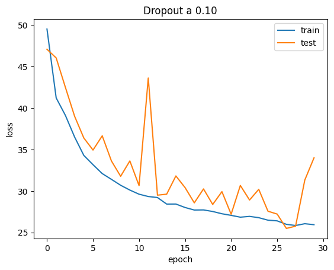

```python
# Modificando el valor de la capa Dropout a 0.1
plt.plot(hist15.history['loss'], label="train")
plt.plot(hist15.history['val_loss'], label="test")
plt.title('Dropout a 0.10')
plt.ylabel('loss')
plt.xlabel('epoch')
plt.legend()
```

*Se podrían hacer más pruebas para dar con un resultado que nos satisface más.*

```python
%%shell
jupyter nbconvert --to html ///content/Caso-Practico_Mariya.ipynb
```

```
[NbConvertApp] Converting notebook ///content/Caso-Practico_Mariya.ipynb to html
[NbConvertApp] Writing 1322119 bytes to /content/Caso-Practico_Mariya.html
```